# Part II - (Top Factors Having The Most Effect On Trip Duration and Determining Day-Time of Most Number of Trips)

## by (Adewunmi Olowu)

## Investigation Overview

> The aim of this investigation was to determine what factors contributed largely to the average time spent on a ride as well as understanding what day and time most rides were taken. Factors majorly focused on included start_periodofday, member_gender and start_dayofweek.

## Dataset Overview

> This document explores a dataset that includes information about individual rides made in a bike-sharing system covering the greater San Francisco Bay area.

## Frequency of Trips

In order to understand the time period and day of the week that usually have the most number of rides.A countplot was used to deduce that Thursday evenings records the most number of rides.

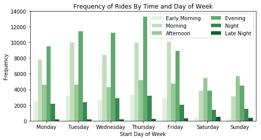

## Distribution of Duration

> Let's take a look at the distribution of the variable- duration_sec using a log transformation considering the range of values. We see the distribution looks unimodal, with its peak between 500 and 1000. A few outliers are noticed from 30000 upwards.

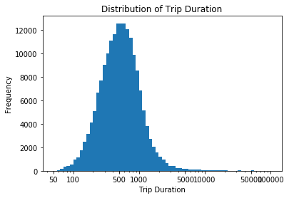

## Relationship Between Duration and Day of Week, Time Period, Gender

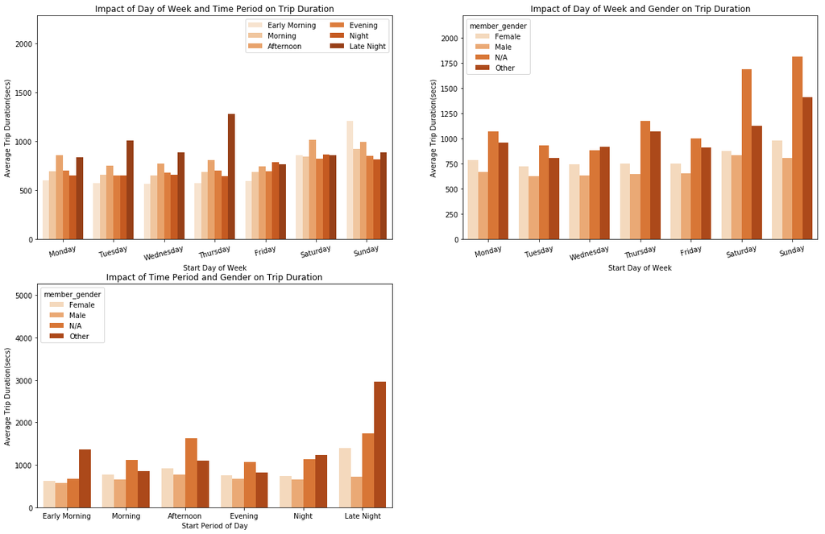